# The r3PG R package

Volodymyr Trotsiuk, Florian Hartig, David I. Forrester

2020-03-23

Abstract

This vignette provides an overview of the r3PG R package functions and options.

## Prerequisite

In order to reproduce all the examples, please make sure that the below listed r packages are installed.

```r
library(r3PG)

library(dplyr)
library(tidyr)
library(purrr)

library(ggplot2)

library(BayesianTools)
library(sensitivity)
```

We also have prepared an input data required for the model calibration and simulations on Swiss scale.

```r
load('vignette_data/solling.rda')
```

## Single model runs

To demonstrate the basic functionality of the `r3PG` R package, we will perform a simple simulations with the `3-PGmix` model. The central function to run `3-PG` from within R is `run_3PG`. When called, the function will:

- check the model input for the consistency in structure
- replace the default parameters if new ones are provided
- run and return the simulated output from the model.

Before using `run_3PG` it is required that the user prepares the input data as described in the package description. In particular, it is important to prepare information about site conditions, species initial conditions, climate data, and parameters (if they need to be modified). In the example presented, we run a simulation for the mixed *Fagus sylvatica* and *Pinus sylvestris* stands **(REF)**. The input data are provided in the package. The output of the `run_3PG` function is a list with 2 objects: *sp_info* - information about species names and simulation start; *sim* - actual simulation of the model. The *sim* object is a 4-dimentional array where each row corresponds to one month of simulations. The second dimension corresponds to species, where each column represents one species. The third dimension corresponds to variable groups and the variables themselves To get the information about output variables and their group, please look at `data('output_info')`.

```r
out <- run_3PG(
  siteInputs = site_eum,
  speciesInputs = species_eum,
  forcingInputs = climate_eum,
  managementInputs = NULL,
  parameterInputs = parameters_eum,
  biasInputs = bias_eum,
  settings = list(light_model = 2, transp_model = 2, phys_model = 2,
    correct_bias = 1, calculate_d13c = 0),
  df_out = FALSE)

str(out)
```

```
#> List of 2
#>  $ sp_info:'data.frame': 2 obs. of  3 variables:
#>   ..$ species: Factor w/ 2 levels "Fagus sylvatica",..: 1 2
#>   ..$ year_i : num [1:2] 2002 2002
#>   ..$ month_i: num [1:2] 1 1
#>  $ sim    : num [1:156, 1:2, 1:10, 1:15] -3.09 2.72 1.45 4.02 9.17 ...
```

For easy use and exploration, we convert the default model output into the long format using function `tranf_out`. This function puts all the data into long format, where each row corresponds to one observational value, assigned to data, species, and variable names.

```r
out_long <- transf_out( out )

head( out_long )
```

```
#>         date         species   group variable     value
#> 1 2002-01-31 Fagus sylvatica climate  tmp_min -3.092466
#> 2 2002-02-28 Fagus sylvatica climate  tmp_min  2.724698
#> 3 2002-03-31 Fagus sylvatica climate  tmp_min  1.452504
#> 4 2002-04-30 Fagus sylvatica climate  tmp_min  4.015618
#> 5 2002-05-31 Fagus sylvatica climate  tmp_min  9.174515
#> 6 2002-06-30 Fagus sylvatica climate  tmp_min 12.991696
```

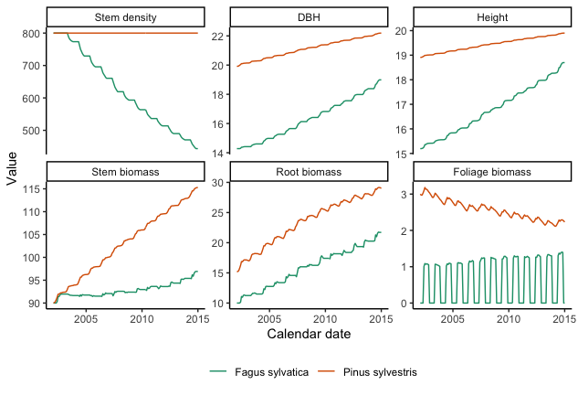

```r
i_var <- c('stems_n',  'dbh', 'height', 'biom_stem', 'biom_root', 'biom_foliage')
i_lab <- c('Stem density', 'DBH', 'Height', 'Stem biomass', 'Root biomass', 'Foliage biomass')


out_long %>%
  filter(variable %in% i_var) %>%
  mutate(variable = factor(variable, levels = i_var)) %>%
  ggplot( aes(date, value))+
  geom_line( aes(color = species), size = 0.5)+
  facet_wrap( ~ variable, scales = 'free_y', ncol = 3,
    labeller = labeller(variable = setNames(i_lab, i_var) )) +
  scale_color_brewer('', palette = 'Dark2') +
  theme_classic()+
  theme(legend.position="bottom")+
  xlab("Calendar date") + ylab('Value')
```

## Sensitivity analysis and Bayesian calibration

As a second example, we will first performed a Morris screening and then perform the Bayesian calibration of 3-PGpjs model. We will be using freely available forest growth data from the [PROFOUND database](https://doi.org/10.5194/essd-2019-220) for the analysis. We will use the `solling` site, dominated by *Pice abies*.

### Likelihood function

To perform a `morris` sensitivity analysis and `Bayesian calibration` we construct the log-likelihood function. For this purpose, we will use observational data for: *basal area*, *dbh*, *height*, *stem biomass*, *foliage biomass*, and *root biomass*. In addition, we need to provide error parameters for all of those observational data. We will be using a faster function for running the 3-PG model - `f_3PG`. This function assumes that all input data are correct and avoids checking the input data, in contrast to the default `run_3PG`. Before using `f_3PG` make sure that you provide data in the required form.

```r
r3pg_ll <- function( pars ){
  #' @param pars a vector of parameters for the calibration, including errors

  # replace the default values for the selected parameters
  pars <- setNames(pars, par_cal_names)

  par_def[which( names(par_def) %in% par_cal_names)] <- pars[-grep('err', par_cal_names)]
  err_def <- pars[grep('err', par_cal_names)]

  # simulate the model
  sim.df <- f_3PG(
    siteInputs = site_solling,
    speciesInputs = species_solling,
    forcingInputs = climate_solling,
    managementInputs = thinn_solling,
    parameterInputs = par_def,
    biasInputs = matrix(NA_real_, nrow = 30, ncol = 2 ),
    n_sp = 1L, n_m = 552L, n_man = 14L, t_t = 14L,
    settings = c(1L, 1L, 1L, 0L, 0L), sp_names = 'piab', df_out = FALSE )$sim

  sim.df <- cbind(sim.df[,,2,c(3,5,6)], sim.df[,,4,c(1,2,3)])

  # calculate the log likelihood
  logpost <- sapply(1:6, function(i) likelihoodIidNormal( sim.df[,i], observ_solling_mat[,i], err_def[i] ) )
  logpost <- sum( logpost )

  if(is.nan(logpost) | is.na(logpost) | logpost == 0 ){logpost <- -Inf}

  return( logpost )
}
```

### Priors and default

For Morris sensitivity analysis and Bayesian callibration we define the parameters range, for which we will evaluate first the sensitivity and later perform calibration.

```r
# default parameters
par_def <- setNames(param_solling$default, param_solling$param_name)
err_def <- setNames(error_solling$default, error_solling$param_name)

# parameters for callibration and their ranges
param_morris.df <- bind_rows(param_solling, error_solling) %>% filter(!is.na(min))
par_cal_names <- param_morris.df$param_name
par_cal_min <- param_morris.df$min
par_cal_max <- param_morris.df$max
par_cal_best <- param_morris.df$default

r3pg_ll( par_cal_best)
```

```
#> [1] -200.2997
```

### Morris sensitivity

With below specified settings we will run a total of 11600 model runs (N (length(factors)+1)) and visualize the results The morris sensitivity run will take approximately 4 minutes on the working computer.

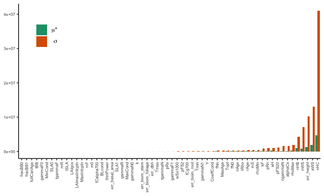

```r
morris_setup <- createBayesianSetup(
  likelihood = r3pg_ll,
  prior = createUniformPrior(par_cal_min, par_cal_max, par_cal_best),
  names = par_cal_names)

morrisOut <- morris(
  model = morris_setup$posterior$density,
  factors = par_cal_names,
  r = 200,
  design = list(type = "oat", levels = 20, grid.jump = 3),
  binf = par_cal_min,
  bsup = par_cal_max,
  scale = TRUE)

# summarise the moris output
morrisOut.df <- data.frame(
  parameter = par_cal_names,
  mu.star = apply(abs(morrisOut$ee), 2, mean, na.rm = T),
  sigma = apply(morrisOut$ee, 2, sd, na.rm = T)
) %>%
  arrange( mu.star )

morrisOut.df %>%
  gather(variable, value, -parameter) %>%
  ggplot(aes(reorder(parameter, value), value, fill = variable), color = NA)+
  geom_bar(position = position_dodge(), stat = 'identity') +
  scale_fill_brewer("", labels = c('mu.star' = expression(mu * "*"), 'sigma' = expression(sigma)), palette="Dark2") +
  theme_classic() +
  theme(
    axis.text = element_text(size = 6),
    axis.text.x = element_text(angle=90, hjust=1, vjust = 0.5),
    axis.title = element_blank(),
    legend.position = c(0.05 ,0.95),legend.justification = c(0.05,0.95)
  )
```